# Głoski dźwięczne i bezdźwięczne

Jako trochę bardziej skomplikowany przykład, zobaczmy następującą hipotezę: wyraz **w** ulegnie ubezdźwięcznieniu, jeśli po nim następuje wyraz zaczynający się od głoski bezdźwięcznej i analogicznie pozostanie dźwięczny w przypadku głoski dźwięcznej. Na przykład:

- w drużynie - **w** jest dźwięczne (czyli *v*)
- w samochodzie - **w** jest bezdźwięczne (czyli *f*)

Wczytajmy naszą bazę:

```r
library(emuR)
db <- load_emuDB('clarin', verbose = FALSE)
```

Zobaczmy, ile jest w ogóle wyrazów **w** w korpusie:

```r
segs_all <- query(db,'[Word == w]')
```

Z tych 230 przykładów zróbmy podział na takie, po których następują głoski dźwięczne i bezdźwięczne:

```r
segs_unv <- query(db,'[Word == w -> [Word =~ .* ^ [Phoneme == t | p | s | S | tS | tsi | si | f | x | k | ts & Start(Word,Phoneme)==1]]]')
segs_voi <- query(db,'[Word == w -> [Word =~ .* ^ [Phoneme != t | p | s | S | tS | tsi | si | f | x | k | ts & Start(Word,Phoneme)==1]]]')
```

Kwerenda ta jest trochę bardziej skomplikowana, więc rozbijmy ją na posczególne części:

- szukamy wyrazu **w**
- po tym wyrazie (znak `->` oznacza następstwo) występuje to, co w nawiasie kwadratowym
- może to być dowolny wyraz (znak `.*` oznacza dowolną sekwencję znaków - jeśli używamy wyrażeń regularnych, musimy też stosować symobl `=~` zamiast prostej równości)
- w innym poziomie tego wyrazu musi występować fonem z listy
- fonem ten musi być na pierwszym miejscu w wyrazie

Widać, że tutaj znowu mamy szczęście i liczność obydwu grup segmentów jest mniej więcej równa:

```r
length(segs_voi[,1])
```

[output not shown]

```r
length(segs_unv[,1])
```

[output not shown]

Jak spojrzymy na zawartość jednego z tych segmentów, zobaczymy, że opis każdego zawiera zarówno wyraz **w**, jak i to, co następuje po nim:

```r
segs_unv$labels[1:10]
```

```
 [1] "w->szkole"       "w->pierwszych"   "w->ciemnościach" "w->prostokątnej" "w->kraju"        "w->którym"       "w->tych"
 [8] "w->świecie"      "w->tym"          "w->posiadaniu"
```

Możemy użyć następującego polecenia, żeby wybrać tylko te części segmentów należące do wyrazu **w**:

```r
w_unv=requery_seq(db,segs_unv)
w_voi=requery_seq(db,segs_voi)
```

Następnie, użyjmy poniższego polecenia, żeby odczytać annotację wyrazu na poziomie fonemów, zamiast wyrazu:

```r
ph_unv=requery_hier(db,w_unv,'Phoneme')
ph_voi=requery_hier(db,w_voi,'Phoneme')
```

Zróbmy teraz tabelę podsumowującą:

```r
d_voi=data.frame(voicness=rep('Dźw.',length(ph_voi[,1])),
                 phoneme=ph_voi$labels)
d_unv=data.frame(voicness=rep('Bezdź.',length(ph_unv[,1])),
                 phoneme=ph_unv$labels)
dt=table(rbind(d_voi,d_unv))
dt
```

```
        phoneme
voicness   f   v
  Dźw.     8 102
  Bezdź. 113   7
```

A na koniec narysujmy wykres:

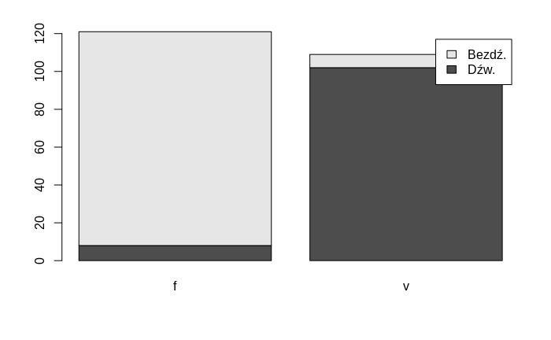

```r
barplot(dt,legend=rownames(dt))
```

W każdym razie celem tego zeszytu było pokazanie w miarę skomplikowanej sytuacji życiowej i kwerendy potrzebnej do jej zrealizowania. Pokazano też dwa dodatkowe polecenia, które się bardzo przydają do doprecyzowania poszukiwanej informacji.